# SICVIR: variables presentes en comunas

## Resumen

### Porcentaje de variables presentes por región y clasificación

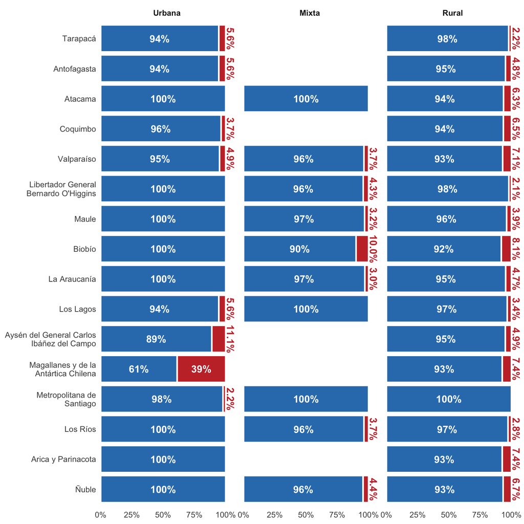

### Variables perdidas por región

Suma de las variables perdidas en cada comuna, por región.

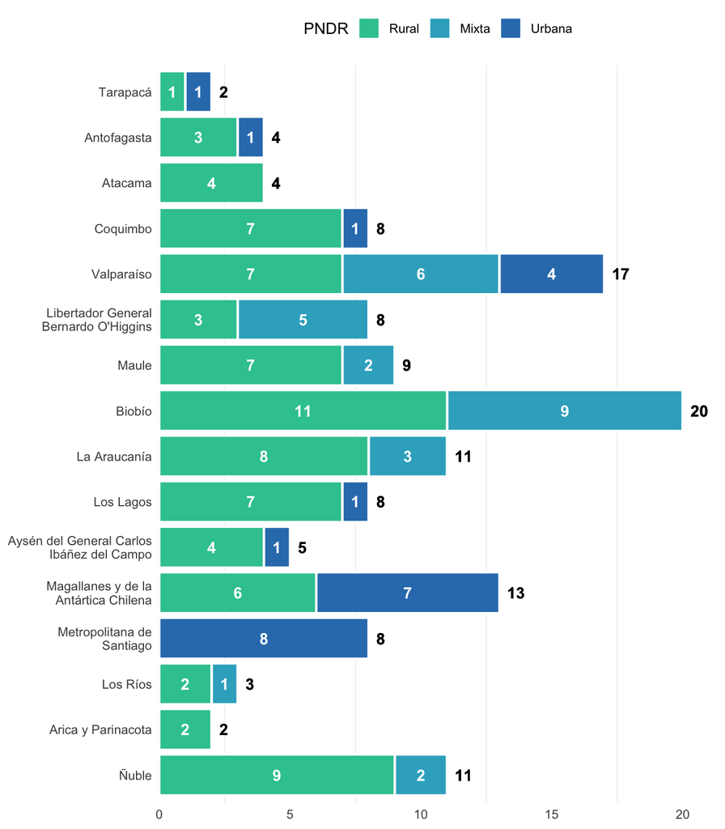

## Tarapacá

### Iquique

*Urbana*

Variables presentes: 9 de 9

Porcentaje de variables presentes: 100%

| bs03 | Tiempo mediano en minutos al recinto de educación básica más cercano | 2021 |
| --- | --- | --- |
| bs04 | Tiempo mediano en minutos al recinto de educación media más cercano | 2021 |
| bs07 | Tiempo mediano en minutos al hospital o clínica más cercana | 2021 |
| bs10 | Tiempo mediano en minutos al cuartel de Carabineros más cercano | 2018 |
| bs12 | Porcentaje de viviendas particulares no conectadas a la red de agua potable | 2017 |
| bs21 | Tiempo mediano en minutos al centro de salud primaria más cercano | 2021 |
| ci04 | Porcentaje de viviendas particulares con cobertura de radiodifusión comunitaria ciudadana | 2021 |
| ci06 | Número de espacios culturales por cada 1.000 habitantes | 2021 |
| sm03 | Cantidad de residuos eliminados con disposición final per cápita | 2022 |

### Alto Hospicio

*Urbana*

Variables presentes: 8 de 9

Porcentaje de variables presentes: 89%

| bs03 | Tiempo mediano en minutos al recinto de educación básica más cercano | 2021 |
| --- | --- | --- |
| bs04 | Tiempo mediano en minutos al recinto de educación media más cercano | 2021 |
| bs07 | Tiempo mediano en minutos al hospital o clínica más cercana | 2021 |
| bs10 | Tiempo mediano en minutos al cuartel de Carabineros más cercano | 2018 |
| bs12 | Porcentaje de viviendas particulares no conectadas a la red de agua potable | 2017 |
| bs21 | Tiempo mediano en minutos al centro de salud primaria más cercano | 2021 |
| ci04 | Porcentaje de viviendas particulares con cobertura de radiodifusión comunitaria ciudadana | 2021 |
| ci06 | Número de espacios culturales por cada 1.000 habitantes | 2021 |
| sm03 | Cantidad de residuos eliminados con disposición final per cápita | 2022 |

### Pozo Almonte

*Rural*

Variables presentes: 9 de 9

Porcentaje de variables presentes: 100%

| bs03 | Tiempo mediano en minutos al recinto de educación básica más cercano | 2021 |
| --- | --- | --- |
| bs04 | Tiempo mediano en minutos al recinto de educación media más cercano | 2021 |
| bs07 | Tiempo mediano en minutos al hospital o clínica más cercana | 2021 |
| bs10 | Tiempo mediano en minutos al cuartel de Carabineros más cercano | 2018 |
| bs12 | Porcentaje de viviendas particulares no conectadas a la red de agua potable | 2017 |
| bs21 | Tiempo mediano en minutos al centro de salud primaria más cercano | 2021 |
| ci04 | Porcentaje de viviendas particulares con cobertura de radiodifusión comunitaria ciudadana | 2021 |
| ci06 | Número de espacios culturales por cada 1.000 habitantes | 2021 |
| sm03 | Cantidad de residuos eliminados con disposición final per cápita | 2022 |

### Camiña

*Rural*

Variables presentes: 9 de 9

Porcentaje de variables presentes: 100%

| bs03 | Tiempo mediano en minutos al recinto de educación básica más cercano | 2021 |
| --- | --- | --- |
| bs04 | Tiempo mediano en minutos al recinto de educación media más cercano | 2021 |
| bs07 | Tiempo mediano en minutos al hospital o clínica más cercana | 2021 |
| bs10 | Tiempo mediano en minutos al cuartel de Carabineros más cercano | 2018 |
| bs12 | Porcentaje de viviendas particulares no conectadas a la red de agua potable | 2017 |
| bs21 | Tiempo mediano en minutos al centro de salud primaria más cercano | 2021 |
| ci04 | Porcentaje de viviendas particulares con cobertura de radiodifusión comunitaria ciudadana | 2021 |
| ci06 | Número de espacios culturales por cada 1.000 habitantes | 2021 |
| sm03 | Cantidad de residuos eliminados con disposición final per cápita | 2022 |

### Colchane

*Rural*

Variables presentes: 9 de 9

Porcentaje de variables presentes: 100%

| bs03 | Tiempo mediano en minutos al recinto de educación básica más cercano | 2021 |
| --- | --- | --- |
| bs04 | Tiempo mediano en minutos al recinto de educación media más cercano | 2021 |
| bs07 | Tiempo mediano en minutos al hospital o clínica más cercana | 2021 |
| bs10 | Tiempo mediano en minutos al cuartel de Carabineros más cercano | 2018 |
| bs12 | Porcentaje de viviendas particulares no conectadas a la red de agua potable | 2017 |
| bs21 | Tiempo mediano en minutos al centro de salud primaria más cercano | 2021 |
| ci04 | Porcentaje de viviendas particulares con cobertura de radiodifusión comunitaria ciudadana | 2021 |
| ci06 | Número de espacios culturales por cada 1.000 habitantes | 2021 |
| sm03 | Cantidad de residuos eliminados con disposición final per cápita | 2022 |

### Huara

*Rural*

Variables presentes: 8 de 9

Porcentaje de variables presentes: 89%

| bs03 | Tiempo mediano en minutos al recinto de educación básica más cercano | 2021 |
| --- | --- | --- |
| bs04 | Tiempo mediano en minutos al recinto de educación media más cercano | 2021 |
| bs07 | Tiempo mediano en minutos al hospital o clínica más cercana | 2021 |
| bs10 | Tiempo mediano en minutos al cuartel de Carabineros más cercano | 2018 |
| bs12 | Porcentaje de viviendas particulares no conectadas a la red de agua potable | 2017 |
| bs21 | Tiempo mediano en minutos al centro de salud primaria más cercano | 2021 |
| ci04 | Porcentaje de viviendas particulares con cobertura de radiodifusión comunitaria ciudadana | 2021 |
| ci06 | Número de espacios culturales por cada 1.000 habitantes | 2021 |
| sm03 | Cantidad de residuos eliminados con disposición final per cápita | 2022 |

### Pica

*Rural*

Variables presentes: 9 de 9

Porcentaje de variables presentes: 100%

| bs03 | Tiempo mediano en minutos al recinto de educación básica más cercano | 2021 |
| --- | --- | --- |
| bs04 | Tiempo mediano en minutos al recinto de educación media más cercano | 2021 |
| bs07 | Tiempo mediano en minutos al hospital o clínica más cercana | 2021 |
| bs10 | Tiempo mediano en minutos al cuartel de Carabineros más cercano | 2018 |
| bs12 | Porcentaje de viviendas particulares no conectadas a la red de agua potable | 2017 |
| bs21 | Tiempo mediano en minutos al centro de salud primaria más cercano | 2021 |
| ci04 | Porcentaje de viviendas particulares con cobertura de radiodifusión comunitaria ciudadana | 2021 |
| ci06 | Número de espacios culturales por cada 1.000 habitantes | 2021 |
| sm03 | Cantidad de residuos eliminados con disposición final per cápita | 2022 |

## Antofagasta

### Antofagasta

*Urbana*

Variables presentes: 9 de 9

Porcentaje de variables presentes: 100%

| bs03 | Tiempo mediano en minutos al recinto de educación básica más cercano | 2021 |
| --- | --- | --- |
| bs04 | Tiempo mediano en minutos al recinto de educación media más cercano | 2021 |
| bs07 | Tiempo mediano en minutos al hospital o clínica más cercana | 2021 |
| bs10 | Tiempo mediano en minutos al cuartel de Carabineros más cercano | 2018 |
| bs12 | Porcentaje de viviendas particulares no conectadas a la red de agua potable | 2017 |
| bs21 | Tiempo mediano en minutos al centro de salud primaria más cercano | 2021 |
| ci04 | Porcentaje de viviendas particulares con cobertura de radiodifusión comunitaria ciudadana | 2021 |
| ci06 | Número de espacios culturales por cada 1.000 habitantes | 2021 |
| sm03 | Cantidad de residuos eliminados con disposición final per cápita | 2022 |

### Mejillones

*Rural*

Variables presentes: 7 de 9

Porcentaje de variables presentes: 78%

| bs03 | Tiempo mediano en minutos al recinto de educación básica más cercano | 2021 |
| --- | --- | --- |
| bs04 | Tiempo mediano en minutos al recinto de educación media más cercano | 2021 |
| bs07 | Tiempo mediano en minutos al hospital o clínica más cercana | 2021 |
| bs10 | Tiempo mediano en minutos al cuartel de Carabineros más cercano | 2018 |
| bs12 | Porcentaje de viviendas particulares no conectadas a la red de agua potable | 2017 |
| bs21 | Tiempo mediano en minutos al centro de salud primaria más cercano | 2021 |
| ci04 | Porcentaje de viviendas particulares con cobertura de radiodifusión comunitaria ciudadana | 2021 |
| ci06 | Número de espacios culturales por cada 1.000 habitantes | 2021 |
| sm03 | Cantidad de residuos eliminados con disposición final per cápita | 2022 |

### Sierra Gorda

*Rural*

Variables presentes: 9 de 9

Porcentaje de variables presentes: 100%

| bs03 | Tiempo mediano en minutos al recinto de educación básica más cercano | 2021 |
| --- | --- | --- |
| bs04 | Tiempo mediano en minutos al recinto de educación media más cercano | 2021 |
| bs07 | Tiempo mediano en minutos al hospital o clínica más cercana | 2021 |
| bs10 | Tiempo mediano en minutos al cuartel de Carabineros más cercano | 2018 |
| bs12 | Porcentaje de viviendas particulares no conectadas a la red de agua potable | 2017 |
| bs21 | Tiempo mediano en minutos al centro de salud primaria más cercano | 2021 |
| ci04 | Porcentaje de viviendas particulares con cobertura de radiodifusión comunitaria ciudadana | 2021 |
| ci06 | Número de espacios culturales por cada 1.000 habitantes | 2021 |
| sm03 | Cantidad de residuos eliminados con disposición final per cápita | 2022 |

### Taltal

*Rural*

Variables presentes: 9 de 9

Porcentaje de variables presentes: 100%

| bs03 | Tiempo mediano en minutos al recinto de educación básica más cercano | 2021 |
| --- | --- | --- |
| bs04 | Tiempo mediano en minutos al recinto de educación media más cercano | 2021 |
| bs07 | Tiempo mediano en minutos al hospital o clínica más cercana | 2021 |
| bs10 | Tiempo mediano en minutos al cuartel de Carabineros más cercano | 2018 |
| bs12 | Porcentaje de viviendas particulares no conectadas a la red de agua potable | 2017 |
| bs21 | Tiempo mediano en minutos al centro de salud primaria más cercano | 2021 |
| ci04 | Porcentaje de viviendas particulares con cobertura de radiodifusión comunitaria ciudadana | 2021 |
| ci06 | Número de espacios culturales por cada 1.000 habitantes | 2021 |
| sm03 | Cantidad de residuos eliminados con disposición final per cápita | 2022 |

### Calama

*Urbana*

Variables presentes: 8 de 9

Porcentaje de variables presentes: 89%

| bs03 | Tiempo mediano en minutos al recinto de educación básica más cercano | 2021 |
| --- | --- | --- |
| bs04 | Tiempo mediano en minutos al recinto de educación media más cercano | 2021 |
| bs07 | Tiempo mediano en minutos al hospital o clínica más cercana | 2021 |
| bs10 | Tiempo mediano en minutos al cuartel de Carabineros más cercano | 2018 |
| bs12 | Porcentaje de viviendas particulares no conectadas a la red de agua potable | 2017 |
| bs21 | Tiempo mediano en minutos al centro de salud primaria más cercano | 2021 |
| ci04 | Porcentaje de viviendas particulares con cobertura de radiodifusión comunitaria ciudadana | 2021 |
| ci06 | Número de espacios culturales por cada 1.000 habitantes | 2021 |
| sm03 | Cantidad de residuos eliminados con disposición final per cápita | 2022 |

### Ollagüe

*Rural*

Variables presentes: 9 de 9

Porcentaje de variables presentes: 100%

| bs03 | Tiempo mediano en minutos al recinto de educación básica más cercano | 2021 |
| --- | --- | --- |
| bs04 | Tiempo mediano en minutos al recinto de educación media más cercano | 2021 |
| bs07 | Tiempo mediano en minutos al hospital o clínica más cercana | 2021 |
| bs10 | Tiempo mediano en minutos al cuartel de Carabineros más cercano | 2018 |
| bs12 | Porcentaje de viviendas particulares no conectadas a la red de agua potable | 2017 |
| bs21 | Tiempo mediano en minutos al centro de salud primaria más cercano | 2021 |
| ci04 | Porcentaje de viviendas particulares con cobertura de radiodifusión comunitaria ciudadana | 2021 |
| ci06 | Número de espacios culturales por cada 1.000 habitantes | 2021 |
| sm03 | Cantidad de residuos eliminados con disposición final per cápita | 2022 |

### San Pedro De Atacama

*Rural*

Variables presentes: 9 de 9

Porcentaje de variables presentes: 100%

| bs03 | Tiempo mediano en minutos al recinto de educación básica más cercano | 2021 |
| --- | --- | --- |
| bs04 | Tiempo mediano en minutos al recinto de educación media más cercano | 2021 |
| bs07 | Tiempo mediano en minutos al hospital o clínica más cercana | 2021 |
| bs10 | Tiempo mediano en minutos al cuartel de Carabineros más cercano | 2018 |
| bs12 | Porcentaje de viviendas particulares no conectadas a la red de agua potable | 2017 |
| bs21 | Tiempo mediano en minutos al centro de salud primaria más cercano | 2021 |
| ci04 | Porcentaje de viviendas particulares con cobertura de radiodifusión comunitaria ciudadana | 2021 |
| ci06 | Número de espacios culturales por cada 1.000 habitantes | 2021 |
| sm03 | Cantidad de residuos eliminados con disposición final per cápita | 2022 |

### Tocopilla

*Rural*

Variables presentes: 9 de 9

Porcentaje de variables presentes: 100%

| bs03 | Tiempo mediano en minutos al recinto de educación básica más cercano | 2021 |
| --- | --- | --- |
| bs04 | Tiempo mediano en minutos al recinto de educación media más cercano | 2021 |
| bs07 | Tiempo mediano en minutos al hospital o clínica más cercana | 2021 |
| bs10 | Tiempo mediano en minutos al cuartel de Carabineros más cercano | 2018 |
| bs12 | Porcentaje de viviendas particulares no conectadas a la red de agua potable | 2017 |
| bs21 | Tiempo mediano en minutos al centro de salud primaria más cercano | 2021 |
| ci04 | Porcentaje de viviendas particulares con cobertura de radiodifusión comunitaria ciudadana | 2021 |
| ci06 | Número de espacios culturales por cada 1.000 habitantes | 2021 |
| sm03 | Cantidad de residuos eliminados con disposición final per cápita | 2022 |

### María Elena

*Rural*

Variables presentes: 8 de 9

Porcentaje de variables presentes: 89%

| bs03 | Tiempo mediano en minutos al recinto de educación básica más cercano | 2021 |
| --- | --- | --- |
| bs04 | Tiempo mediano en minutos al recinto de educación media más cercano | 2021 |
| bs07 | Tiempo mediano en minutos al hospital o clínica más cercana | 2021 |
| bs10 | Tiempo mediano en minutos al cuartel de Carabineros más cercano | 2018 |
| bs12 | Porcentaje de viviendas particulares no conectadas a la red de agua potable | 2017 |
| bs21 | Tiempo mediano en minutos al centro de salud primaria más cercano | 2021 |
| ci04 | Porcentaje de viviendas particulares con cobertura de radiodifusión comunitaria ciudadana | 2021 |
| ci06 | Número de espacios culturales por cada 1.000 habitantes | 2021 |
| sm03 | Cantidad de residuos eliminados con disposición final per cápita | 2022 |

## Atacama

### Copiapó

*Urbana*

Variables presentes: 9 de 9

Porcentaje de variables presentes: 100%

| bs03 | Tiempo mediano en minutos al recinto de educación básica más cercano | 2021 |
| --- | --- | --- |
| bs04 | Tiempo mediano en minutos al recinto de educación media más cercano | 2021 |
| bs07 | Tiempo mediano en minutos al hospital o clínica más cercana | 2021 |
| bs10 | Tiempo mediano en minutos al cuartel de Carabineros más cercano | 2018 |
| bs12 | Porcentaje de viviendas particulares no conectadas a la red de agua potable | 2017 |
| bs21 | Tiempo mediano en minutos al centro de salud primaria más cercano | 2021 |
| ci04 | Porcentaje de viviendas particulares con cobertura de radiodifusión comunitaria ciudadana | 2021 |
| ci06 | Número de espacios culturales por cada 1.000 habitantes | 2021 |
| sm03 | Cantidad de residuos eliminados con disposición final per cápita | 2022 |

### Caldera

*Rural*

Variables presentes: 9 de 9

Porcentaje de variables presentes: 100%

| bs03 | Tiempo mediano en minutos al recinto de educación básica más cercano | 2021 |
| --- | --- | --- |
| bs04 | Tiempo mediano en minutos al recinto de educación media más cercano | 2021 |
| bs07 | Tiempo mediano en minutos al hospital o clínica más cercana | 2021 |
| bs10 | Tiempo mediano en minutos al cuartel de Carabineros más cercano | 2018 |
| bs12 | Porcentaje de viviendas particulares no conectadas a la red de agua potable | 2017 |
| bs21 | Tiempo mediano en minutos al centro de salud primaria más cercano | 2021 |
| ci04 | Porcentaje de viviendas particulares con cobertura de radiodifusión comunitaria ciudadana | 2021 |
| ci06 | Número de espacios culturales por cada 1.000 habitantes | 2021 |
| sm03 | Cantidad de residuos eliminados con disposición final per cápita | 2022 |

### Tierra Amarilla

*Rural*

Variables presentes: 8 de 9

Porcentaje de variables presentes: 89%

| bs03 | Tiempo mediano en minutos al recinto de educación básica más cercano | 2021 |
| --- | --- | --- |
| bs04 | Tiempo mediano en minutos al recinto de educación media más cercano | 2021 |
| bs07 | Tiempo mediano en minutos al hospital o clínica más cercana | 2021 |
| bs10 | Tiempo mediano en minutos al cuartel de Carabineros más cercano | 2018 |
| bs12 | Porcentaje de viviendas particulares no conectadas a la red de agua potable | 2017 |
| bs21 | Tiempo mediano en minutos al centro de salud primaria más cercano | 2021 |
| ci04 | Porcentaje de viviendas particulares con cobertura de radiodifusión comunitaria ciudadana | 2021 |
| ci06 | Número de espacios culturales por cada 1.000 habitantes | 2021 |
| sm03 | Cantidad de residuos eliminados con disposición final per cápita | 2022 |

### Chañaral

*Rural*

Variables presentes: 8 de 9

Porcentaje de variables presentes: 89%

| bs03 | Tiempo mediano en minutos al recinto de educación básica más cercano | 2021 |
| --- | --- | --- |
| bs04 | Tiempo mediano en minutos al recinto de educación media más cercano | 2021 |
| bs07 | Tiempo mediano en minutos al hospital o clínica más cercana | 2021 |
| bs10 | Tiempo mediano en minutos al cuartel de Carabineros más cercano | 2018 |
| bs12 | Porcentaje de viviendas particulares no conectadas a la red de agua potable | 2017 |
| bs21 | Tiempo mediano en minutos al centro de salud primaria más cercano | 2021 |
| ci04 | Porcentaje de viviendas particulares con cobertura de radiodifusión comunitaria ciudadana | 2021 |
| ci06 | Número de espacios culturales por cada 1.000 habitantes | 2021 |
| sm03 | Cantidad de residuos eliminados con disposición final per cápita | 2022 |

### Diego De Almagro

*Rural*

Variables presentes: 8 de 9

Porcentaje de variables presentes: 89%

| bs03 | Tiempo mediano en minutos al recinto de educación básica más cercano | 2021 |
| --- | --- | --- |
| bs04 | Tiempo mediano en minutos al recinto de educación media más cercano | 2021 |
| bs07 | Tiempo mediano en minutos al hospital o clínica más cercana | 2021 |
| bs10 | Tiempo mediano en minutos al cuartel de Carabineros más cercano | 2018 |
| bs12 | Porcentaje de viviendas particulares no conectadas a la red de agua potable | 2017 |
| bs21 | Tiempo mediano en minutos al centro de salud primaria más cercano | 2021 |
| ci04 | Porcentaje de viviendas particulares con cobertura de radiodifusión comunitaria ciudadana | 2021 |
| ci06 | Número de espacios culturales por cada 1.000 habitantes | 2021 |
| sm03 | Cantidad de residuos eliminados con disposición final per cápita | 2022 |

### Vallenar

*Mixta*

Variables presentes: 9 de 9

Porcentaje de variables presentes: 100%

| bs03 | Tiempo mediano en minutos al recinto de educación básica más cercano | 2021 |
| --- | --- | --- |
| bs04 | Tiempo mediano en minutos al recinto de educación media más cercano | 2021 |
| bs07 | Tiempo mediano en minutos al hospital o clínica más cercana | 2021 |
| bs10 | Tiempo mediano en minutos al cuartel de Carabineros más cercano | 2018 |
| bs12 | Porcentaje de viviendas particulares no conectadas a la red de agua potable | 2017 |
| bs21 | Tiempo mediano en minutos al centro de salud primaria más cercano | 2021 |
| ci04 | Porcentaje de viviendas particulares con cobertura de radiodifusión comunitaria ciudadana | 2021 |
| ci06 | Número de espacios culturales por cada 1.000 habitantes | 2021 |
| sm03 | Cantidad de residuos eliminados con disposición final per cápita | 2022 |

### Alto Del Carmen

*Rural*

Variables presentes: 9 de 9

Porcentaje de variables presentes: 100%

| bs03 | Tiempo mediano en minutos al recinto de educación básica más cercano | 2021 |
| --- | --- | --- |
| bs04 | Tiempo mediano en minutos al recinto de educación media más cercano | 2021 |
| bs07 | Tiempo mediano en minutos al hospital o clínica más cercana | 2021 |
| bs10 | Tiempo mediano en minutos al cuartel de Carabineros más cercano | 2018 |
| bs12 | Porcentaje de viviendas particulares no conectadas a la red de agua potable | 2017 |
| bs21 | Tiempo mediano en minutos al centro de salud primaria más cercano | 2021 |
| ci04 | Porcentaje de viviendas particulares con cobertura de radiodifusión comunitaria ciudadana | 2021 |
| ci06 | Número de espacios culturales por cada 1.000 habitantes | 2021 |
| sm03 | Cantidad de residuos eliminados con disposición final per cápita | 2022 |

### Freirina

*Rural*

Variables presentes: 8 de 9

Porcentaje de variables presentes: 89%

| bs03 | Tiempo mediano en minutos al recinto de educación básica más cercano | 2021 |
| --- | --- | --- |
| bs04 | Tiempo mediano en minutos al recinto de educación media más cercano | 2021 |
| bs07 | Tiempo mediano en minutos al hospital o clínica más cercana | 2021 |
| bs10 | Tiempo mediano en minutos al cuartel de Carabineros más cercano | 2018 |
| bs12 | Porcentaje de viviendas particulares no conectadas a la red de agua potable | 2017 |
| bs21 | Tiempo mediano en minutos al centro de salud primaria más cercano | 2021 |
| ci04 | Porcentaje de viviendas particulares con cobertura de radiodifusión comunitaria ciudadana | 2021 |
| ci06 | Número de espacios culturales por cada 1.000 habitantes | 2021 |
| sm03 | Cantidad de residuos eliminados con disposición final per cápita | 2022 |

### Huasco

*Rural*

Variables presentes: 9 de 9

Porcentaje de variables presentes: 100%

| bs03 | Tiempo mediano en minutos al recinto de educación básica más cercano | 2021 |
| --- | --- | --- |
| bs04 | Tiempo mediano en minutos al recinto de educación media más cercano | 2021 |
| bs07 | Tiempo mediano en minutos al hospital o clínica más cercana | 2021 |
| bs10 | Tiempo mediano en minutos al cuartel de Carabineros más cercano | 2018 |
| bs12 | Porcentaje de viviendas particulares no conectadas a la red de agua potable | 2017 |
| bs21 | Tiempo mediano en minutos al centro de salud primaria más cercano | 2021 |
| ci04 | Porcentaje de viviendas particulares con cobertura de radiodifusión comunitaria ciudadana | 2021 |
| ci06 | Número de espacios culturales por cada 1.000 habitantes | 2021 |
| sm03 | Cantidad de residuos eliminados con disposición final per cápita | 2022 |

## Coquimbo

### La Serena

*Urbana*

Variables presentes: 8 de 9

Porcentaje de variables presentes: 89%

| bs03 | Tiempo mediano en minutos al recinto de educación básica más cercano | 2021 |
| --- | --- | --- |
| bs04 | Tiempo mediano en minutos al recinto de educación media más cercano | 2021 |
| bs07 | Tiempo mediano en minutos al hospital o clínica más cercana | 2021 |
| bs10 | Tiempo mediano en minutos al cuartel de Carabineros más cercano | 2018 |
| bs12 | Porcentaje de viviendas particulares no conectadas a la red de agua potable | 2017 |
| bs21 | Tiempo mediano en minutos al centro de salud primaria más cercano | 2021 |
| ci04 | Porcentaje de viviendas particulares con cobertura de radiodifusión comunitaria ciudadana | 2021 |
| ci06 | Número de espacios culturales por cada 1.000 habitantes | 2021 |
| sm03 | Cantidad de residuos eliminados con disposición final per cápita | 2022 |

### Coquimbo

*Urbana*

Variables presentes: 9 de 9

Porcentaje de variables presentes: 100%

| bs03 | Tiempo mediano en minutos al recinto de educación básica más cercano | 2021 |
| --- | --- | --- |
| bs04 | Tiempo mediano en minutos al recinto de educación media más cercano | 2021 |
| bs07 | Tiempo mediano en minutos al hospital o clínica más cercana | 2021 |
| bs10 | Tiempo mediano en minutos al cuartel de Carabineros más cercano | 2018 |
| bs12 | Porcentaje de viviendas particulares no conectadas a la red de agua potable | 2017 |
| bs21 | Tiempo mediano en minutos al centro de salud primaria más cercano | 2021 |
| ci04 | Porcentaje de viviendas particulares con cobertura de radiodifusión comunitaria ciudadana | 2021 |
| ci06 | Número de espacios culturales por cada 1.000 habitantes | 2021 |
| sm03 | Cantidad de residuos eliminados con disposición final per cápita | 2022 |

### Andacollo

*Rural*

Variables presentes: 8 de 9

Porcentaje de variables presentes: 89%

| bs03 | Tiempo mediano en minutos al recinto de educación básica más cercano | 2021 |
| --- | --- | --- |
| bs04 | Tiempo mediano en minutos al recinto de educación media más cercano | 2021 |
| bs07 | Tiempo mediano en minutos al hospital o clínica más cercana | 2021 |
| bs10 | Tiempo mediano en minutos al cuartel de Carabineros más cercano | 2018 |
| bs12 | Porcentaje de viviendas particulares no conectadas a la red de agua potable | 2017 |
| bs21 | Tiempo mediano en minutos al centro de salud primaria más cercano | 2021 |
| ci04 | Porcentaje de viviendas particulares con cobertura de radiodifusión comunitaria ciudadana | 2021 |
| ci06 | Número de espacios culturales por cada 1.000 habitantes | 2021 |
| sm03 | Cantidad de residuos eliminados con disposición final per cápita | 2022 |

### La Higuera

*Rural*

Variables presentes: 8 de 9

Porcentaje de variables presentes: 89%

| bs03 | Tiempo mediano en minutos al recinto de educación básica más cercano | 2021 |
| --- | --- | --- |
| bs04 | Tiempo mediano en minutos al recinto de educación media más cercano | 2021 |
| bs07 | Tiempo mediano en minutos al hospital o clínica más cercana | 2021 |
| bs10 | Tiempo mediano en minutos al cuartel de Carabineros más cercano | 2018 |
| bs12 | Porcentaje de viviendas particulares no conectadas a la red de agua potable | 2017 |
| bs21 | Tiempo mediano en minutos al centro de salud primaria más cercano | 2021 |
| ci04 | Porcentaje de viviendas particulares con cobertura de radiodifusión comunitaria ciudadana | 2021 |
| ci06 | Número de espacios culturales por cada 1.000 habitantes | 2021 |
| sm03 | Cantidad de residuos eliminados con disposición final per cápita | 2022 |

### Paiguano

*Rural*

Variables presentes: 8 de 9

Porcentaje de variables presentes: 89%

| bs03 | Tiempo mediano en minutos al recinto de educación básica más cercano | 2021 |
| --- | --- | --- |
| bs04 | Tiempo mediano en minutos al recinto de educación media más cercano | 2021 |
| bs07 | Tiempo mediano en minutos al hospital o clínica más cercana | 2021 |
| bs10 | Tiempo mediano en minutos al cuartel de Carabineros más cercano | 2018 |
| bs12 | Porcentaje de viviendas particulares no conectadas a la red de agua potable | 2017 |
| bs21 | Tiempo mediano en minutos al centro de salud primaria más cercano | 2021 |
| ci04 | Porcentaje de viviendas particulares con cobertura de radiodifusión comunitaria ciudadana | 2021 |
| ci06 | Número de espacios culturales por cada 1.000 habitantes | 2021 |
| sm03 | Cantidad de residuos eliminados con disposición final per cápita | 2022 |

### Vicuña

*Rural*

Variables presentes: 9 de 9

Porcentaje de variables presentes: 100%

| bs03 | Tiempo mediano en minutos al recinto de educación básica más cercano | 2021 |
| --- | --- | --- |
| bs04 | Tiempo mediano en minutos al recinto de educación media más cercano | 2021 |
| bs07 | Tiempo mediano en minutos al hospital o clínica más cercana | 2021 |
| bs10 | Tiempo mediano en minutos al cuartel de Carabineros más cercano | 2018 |
| bs12 | Porcentaje de viviendas particulares no conectadas a la red de agua potable | 2017 |
| bs21 | Tiempo mediano en minutos al centro de salud primaria más cercano | 2021 |
| ci04 | Porcentaje de viviendas particulares con cobertura de radiodifusión comunitaria ciudadana | 2021 |
| ci06 | Número de espacios culturales por cada 1.000 habitantes | 2021 |
| sm03 | Cantidad de residuos eliminados con disposición final per cápita | 2022 |

### Illapel

*Rural*

Variables presentes: 9 de 9

Porcentaje de variables presentes: 100%

| bs03 | Tiempo mediano en minutos al recinto de educación básica más cercano | 2021 |
| --- | --- | --- |
| bs04 | Tiempo mediano en minutos al recinto de educación media más cercano | 2021 |
| bs07 | Tiempo mediano en minutos al hospital o clínica más cercana | 2021 |
| bs10 | Tiempo mediano en minutos al cuartel de Carabineros más cercano | 2018 |
| bs12 | Porcentaje de viviendas particulares no conectadas a la red de agua potable | 2017 |
| bs21 | Tiempo mediano en minutos al centro de salud primaria más cercano | 2021 |
| ci04 | Porcentaje de viviendas particulares con cobertura de radiodifusión comunitaria ciudadana | 2021 |
| ci06 | Número de espacios culturales por cada 1.000 habitantes | 2021 |
| sm03 | Cantidad de residuos eliminados con disposición final per cápita | 2022 |

### Canela

*Rural*

Variables presentes: 8 de 9

Porcentaje de variables presentes: 89%

| bs03 | Tiempo mediano en minutos al recinto de educación básica más cercano | 2021 |
| --- | --- | --- |
| bs04 | Tiempo mediano en minutos al recinto de educación media más cercano | 2021 |
| bs07 | Tiempo mediano en minutos al hospital o clínica más cercana | 2021 |
| bs10 | Tiempo mediano en minutos al cuartel de Carabineros más cercano | 2018 |
| bs12 | Porcentaje de viviendas particulares no conectadas a la red de agua potable | 2017 |
| bs21 | Tiempo mediano en minutos al centro de salud primaria más cercano | 2021 |
| ci04 | Porcentaje de viviendas particulares con cobertura de radiodifusión comunitaria ciudadana | 2021 |
| ci06 | Número de espacios culturales por cada 1.000 habitantes | 2021 |
| sm03 | Cantidad de residuos eliminados con disposición final per cápita | 2022 |

### Los Vilos

*Rural*

Variables presentes: 8 de 9

Porcentaje de variables presentes: 89%

| bs03 | Tiempo mediano en minutos al recinto de educación básica más cercano | 2021 |
| --- | --- | --- |
| bs04 | Tiempo mediano en minutos al recinto de educación media más cercano | 2021 |
| bs07 | Tiempo mediano en minutos al hospital o clínica más cercana | 2021 |
| bs10 | Tiempo mediano en minutos al cuartel de Carabineros más cercano | 2018 |
| bs12 | Porcentaje de viviendas particulares no conectadas a la red de agua potable | 2017 |
| bs21 | Tiempo mediano en minutos al centro de salud primaria más cercano | 2021 |
| ci04 | Porcentaje de viviendas particulares con cobertura de radiodifusión comunitaria ciudadana | 2021 |
| ci06 | Número de espacios culturales por cada 1.000 habitantes | 2021 |
| sm03 | Cantidad de residuos eliminados con disposición final per cápita | 2022 |

### Salamanca

*Rural*

Variables presentes: 9 de 9

Porcentaje de variables presentes: 100%

| bs03 | Tiempo mediano en minutos al recinto de educación básica más cercano | 2021 |
| --- | --- | --- |
| bs04 | Tiempo mediano en minutos al recinto de educación media más cercano | 2021 |
| bs07 | Tiempo mediano en minutos al hospital o clínica más cercana | 2021 |
| bs10 | Tiempo mediano en minutos al cuartel de Carabineros más cercano | 2018 |
| bs12 | Porcentaje de viviendas particulares no conectadas a la red de agua potable | 2017 |
| bs21 | Tiempo mediano en minutos al centro de salud primaria más cercano | 2021 |
| ci04 | Porcentaje de viviendas particulares con cobertura de radiodifusión comunitaria ciudadana | 2021 |
| ci06 | Número de espacios culturales por cada 1.000 habitantes | 2021 |
| sm03 | Cantidad de residuos eliminados con disposición final per cápita | 2022 |

### Ovalle

*Urbana*

Variables presentes: 9 de 9

Porcentaje de variables presentes: 100%

| bs03 | Tiempo mediano en minutos al recinto de educación básica más cercano | 2021 |
| --- | --- | --- |
| bs04 | Tiempo mediano en minutos al recinto de educación media más cercano | 2021 |
| bs07 | Tiempo mediano en minutos al hospital o clínica más cercana | 2021 |
| bs10 | Tiempo mediano en minutos al cuartel de Carabineros más cercano | 2018 |
| bs12 | Porcentaje de viviendas particulares no conectadas a la red de agua potable | 2017 |
| bs21 | Tiempo mediano en minutos al centro de salud primaria más cercano | 2021 |
| ci04 | Porcentaje de viviendas particulares con cobertura de radiodifusión comunitaria ciudadana | 2021 |
| ci06 | Número de espacios culturales por cada 1.000 habitantes | 2021 |
| sm03 | Cantidad de residuos eliminados con disposición final per cápita | 2022 |

### Combarbalá

*Rural*

Variables presentes: 8 de 9

Porcentaje de variables presentes: 89%

| bs03 | Tiempo mediano en minutos al recinto de educación básica más cercano | 2021 |
| --- | --- | --- |
| bs04 | Tiempo mediano en minutos al recinto de educación media más cercano | 2021 |
| bs07 | Tiempo mediano en minutos al hospital o clínica más cercana | 2021 |
| bs10 | Tiempo mediano en minutos al cuartel de Carabineros más cercano | 2018 |
| bs12 | Porcentaje de viviendas particulares no conectadas a la red de agua potable | 2017 |
| bs21 | Tiempo mediano en minutos al centro de salud primaria más cercano | 2021 |
| ci04 | Porcentaje de viviendas particulares con cobertura de radiodifusión comunitaria ciudadana | 2021 |
| ci06 | Número de espacios culturales por cada 1.000 habitantes | 2021 |
| sm03 | Cantidad de residuos eliminados con disposición final per cápita | 2022 |

### Monte Patria

*Rural*

Variables presentes: 9 de 9

Porcentaje de variables presentes: 100%

| bs03 | Tiempo mediano en minutos al recinto de educación básica más cercano | 2021 |
| --- | --- | --- |
| bs04 | Tiempo mediano en minutos al recinto de educación media más cercano | 2021 |
| bs07 | Tiempo mediano en minutos al hospital o clínica más cercana | 2021 |
| bs10 | Tiempo mediano en minutos al cuartel de Carabineros más cercano | 2018 |
| bs12 | Porcentaje de viviendas particulares no conectadas a la red de agua potable | 2017 |
| bs21 | Tiempo mediano en minutos al centro de salud primaria más cercano | 2021 |
| ci04 | Porcentaje de viviendas particulares con cobertura de radiodifusión comunitaria ciudadana | 2021 |
| ci06 | Número de espacios culturales por cada 1.000 habitantes | 2021 |
| sm03 | Cantidad de residuos eliminados con disposición final per cápita | 2022 |

### Punitaqui

*Rural*

Variables presentes: 9 de 9

Porcentaje de variables presentes: 100%

| bs03 | Tiempo mediano en minutos al recinto de educación básica más cercano | 2021 |
| --- | --- | --- |
| bs04 | Tiempo mediano en minutos al recinto de educación media más cercano | 2021 |
| bs07 | Tiempo mediano en minutos al hospital o clínica más cercana | 2021 |
| bs10 | Tiempo mediano en minutos al cuartel de Carabineros más cercano | 2018 |
| bs12 | Porcentaje de viviendas particulares no conectadas a la red de agua potable | 2017 |
| bs21 | Tiempo mediano en minutos al centro de salud primaria más cercano | 2021 |
| ci04 | Porcentaje de viviendas particulares con cobertura de radiodifusión comunitaria ciudadana | 2021 |
| ci06 | Número de espacios culturales por cada 1.000 habitantes | 2021 |
| sm03 | Cantidad de residuos eliminados con disposición final per cápita | 2022 |

### Río Hurtado

*Rural*

Variables presentes: 8 de 9

Porcentaje de variables presentes: 89%

| bs03 | Tiempo mediano en minutos al recinto de educación básica más cercano | 2021 |
| --- | --- | --- |
| bs04 | Tiempo mediano en minutos al recinto de educación media más cercano | 2021 |
| bs07 | Tiempo mediano en minutos al hospital o clínica más cercana | 2021 |
| bs10 | Tiempo mediano en minutos al cuartel de Carabineros más cercano | 2018 |
| bs12 | Porcentaje de viviendas particulares no conectadas a la red de agua potable | 2017 |
| bs21 | Tiempo mediano en minutos al centro de salud primaria más cercano | 2021 |
| ci04 | Porcentaje de viviendas particulares con cobertura de radiodifusión comunitaria ciudadana | 2021 |
| ci06 | Número de espacios culturales por cada 1.000 habitantes | 2021 |
| sm03 | Cantidad de residuos eliminados con disposición final per cápita | 2022 |

## Valparaíso

### Valparaíso

*Urbana*

Variables presentes: 9 de 9

Porcentaje de variables presentes: 100%

| bs03 | Tiempo mediano en minutos al recinto de educación básica más cercano | 2021 |
| --- | --- | --- |
| bs04 | Tiempo mediano en minutos al recinto de educación media más cercano | 2021 |
| bs07 | Tiempo mediano en minutos al hospital o clínica más cercana | 2021 |
| bs10 | Tiempo mediano en minutos al cuartel de Carabineros más cercano | 2018 |
| bs12 | Porcentaje de viviendas particulares no conectadas a la red de agua potable | 2017 |
| bs21 | Tiempo mediano en minutos al centro de salud primaria más cercano | 2021 |
| ci04 | Porcentaje de viviendas particulares con cobertura de radiodifusión comunitaria ciudadana | 2021 |
| ci06 | Número de espacios culturales por cada 1.000 habitantes | 2021 |
| sm03 | Cantidad de residuos eliminados con disposición final per cápita | 2022 |

### Casablanca

*Mixta*

Variables presentes: 9 de 9

Porcentaje de variables presentes: 100%

| bs03 | Tiempo mediano en minutos al recinto de educación básica más cercano | 2021 |
| --- | --- | --- |
| bs04 | Tiempo mediano en minutos al recinto de educación media más cercano | 2021 |
| bs07 | Tiempo mediano en minutos al hospital o clínica más cercana | 2021 |
| bs10 | Tiempo mediano en minutos al cuartel de Carabineros más cercano | 2018 |
| bs12 | Porcentaje de viviendas particulares no conectadas a la red de agua potable | 2017 |
| bs21 | Tiempo mediano en minutos al centro de salud primaria más cercano | 2021 |
| ci04 | Porcentaje de viviendas particulares con cobertura de radiodifusión comunitaria ciudadana | 2021 |
| ci06 | Número de espacios culturales por cada 1.000 habitantes | 2021 |
| sm03 | Cantidad de residuos eliminados con disposición final per cápita | 2022 |

### Concón

*Mixta*

Variables presentes: 9 de 9

Porcentaje de variables presentes: 100%

| bs03 | Tiempo mediano en minutos al recinto de educación básica más cercano | 2021 |
| --- | --- | --- |
| bs04 | Tiempo mediano en minutos al recinto de educación media más cercano | 2021 |
| bs07 | Tiempo mediano en minutos al hospital o clínica más cercana | 2021 |
| bs10 | Tiempo mediano en minutos al cuartel de Carabineros más cercano | 2018 |
| bs12 | Porcentaje de viviendas particulares no conectadas a la red de agua potable | 2017 |
| bs21 | Tiempo mediano en minutos al centro de salud primaria más cercano | 2021 |
| ci04 | Porcentaje de viviendas particulares con cobertura de radiodifusión comunitaria ciudadana | 2021 |
| ci06 | Número de espacios culturales por cada 1.000 habitantes | 2021 |
| sm03 | Cantidad de residuos eliminados con disposición final per cápita | 2022 |

### Juan Fernández

*Rural*

Variables presentes: 7 de 9

Porcentaje de variables presentes: 78%

| bs03 | Tiempo mediano en minutos al recinto de educación básica más cercano | 2021 |
| --- | --- | --- |
| bs04 | Tiempo mediano en minutos al recinto de educación media más cercano | 2021 |
| bs07 | Tiempo mediano en minutos al hospital o clínica más cercana | 2021 |
| bs10 | Tiempo mediano en minutos al cuartel de Carabineros más cercano | 2018 |
| bs12 | Porcentaje de viviendas particulares no conectadas a la red de agua potable | 2017 |
| bs21 | Tiempo mediano en minutos al centro de salud primaria más cercano | 2021 |
| ci04 | Porcentaje de viviendas particulares con cobertura de radiodifusión comunitaria ciudadana | 2021 |
| ci06 | Número de espacios culturales por cada 1.000 habitantes | 2021 |
| sm03 | Cantidad de residuos eliminados con disposición final per cápita | 2022 |

### Puchuncaví

*Mixta*

Variables presentes: 8 de 9

Porcentaje de variables presentes: 89%

| bs03 | Tiempo mediano en minutos al recinto de educación básica más cercano | 2021 |
| --- | --- | --- |
| bs04 | Tiempo mediano en minutos al recinto de educación media más cercano | 2021 |
| bs07 | Tiempo mediano en minutos al hospital o clínica más cercana | 2021 |
| bs10 | Tiempo mediano en minutos al cuartel de Carabineros más cercano | 2018 |
| bs12 | Porcentaje de viviendas particulares no conectadas a la red de agua potable | 2017 |
| bs21 | Tiempo mediano en minutos al centro de salud primaria más cercano | 2021 |
| ci04 | Porcentaje de viviendas particulares con cobertura de radiodifusión comunitaria ciudadana | 2021 |
| ci06 | Número de espacios culturales por cada 1.000 habitantes | 2021 |
| sm03 | Cantidad de residuos eliminados con disposición final per cápita | 2022 |

### Quintero

*Mixta*

Variables presentes: 9 de 9

Porcentaje de variables presentes: 100%

| bs03 | Tiempo mediano en minutos al recinto de educación básica más cercano | 2021 |
| --- | --- | --- |
| bs04 | Tiempo mediano en minutos al recinto de educación media más cercano | 2021 |
| bs07 | Tiempo mediano en minutos al hospital o clínica más cercana | 2021 |
| bs10 | Tiempo mediano en minutos al cuartel de Carabineros más cercano | 2018 |
| bs12 | Porcentaje de viviendas particulares no conectadas a la red de agua potable | 2017 |
| bs21 | Tiempo mediano en minutos al centro de salud primaria más cercano | 2021 |
| ci04 | Porcentaje de viviendas particulares con cobertura de radiodifusión comunitaria ciudadana | 2021 |
| ci06 | Número de espacios culturales por cada 1.000 habitantes | 2021 |
| sm03 | Cantidad de residuos eliminados con disposición final per cápita | 2022 |

### Viña Del Mar

*Urbana*

Variables presentes: 9 de 9

Porcentaje de variables presentes: 100%

| bs03 | Tiempo mediano en minutos al recinto de educación básica más cercano | 2021 |
| --- | --- | --- |
| bs04 | Tiempo mediano en minutos al recinto de educación media más cercano | 2021 |
| bs07 | Tiempo mediano en minutos al hospital o clínica más cercana | 2021 |
| bs10 | Tiempo mediano en minutos al cuartel de Carabineros más cercano | 2018 |
| bs12 | Porcentaje de viviendas particulares no conectadas a la red de agua potable | 2017 |
| bs21 | Tiempo mediano en minutos al centro de salud primaria más cercano | 2021 |
| ci04 | Porcentaje de viviendas particulares con cobertura de radiodifusión comunitaria ciudadana | 2021 |
| ci06 | Número de espacios culturales por cada 1.000 habitantes | 2021 |
| sm03 | Cantidad de residuos eliminados con disposición final per cápita | 2022 |

### Isla De Pascua

*Rural*

Variables presentes: 8 de 9

Porcentaje de variables presentes: 89%

| bs03 | Tiempo mediano en minutos al recinto de educación básica más cercano | 2021 |
| --- | --- | --- |
| bs04 | Tiempo mediano en minutos al recinto de educación media más cercano | 2021 |
| bs07 | Tiempo mediano en minutos al hospital o clínica más cercana | 2021 |
| bs10 | Tiempo mediano en minutos al cuartel de Carabineros más cercano | 2018 |
| bs12 | Porcentaje de viviendas particulares no conectadas a la red de agua potable | 2017 |
| bs21 | Tiempo mediano en minutos al centro de salud primaria más cercano | 2021 |
| ci04 | Porcentaje de viviendas particulares con cobertura de radiodifusión comunitaria ciudadana | 2021 |
| ci06 | Número de espacios culturales por cada 1.000 habitantes | 2021 |
| sm03 | Cantidad de residuos eliminados con disposición final per cápita | 2022 |

### Los Andes

*Urbana*

Variables presentes: 9 de 9

Porcentaje de variables presentes: 100%

| bs03 | Tiempo mediano en minutos al recinto de educación básica más cercano | 2021 |
| --- | --- | --- |
| bs04 | Tiempo mediano en minutos al recinto de educación media más cercano | 2021 |
| bs07 | Tiempo mediano en minutos al hospital o clínica más cercana | 2021 |
| bs10 | Tiempo mediano en minutos al cuartel de Carabineros más cercano | 2018 |
| bs12 | Porcentaje de viviendas particulares no conectadas a la red de agua potable | 2017 |
| bs21 | Tiempo mediano en minutos al centro de salud primaria más cercano | 2021 |
| ci04 | Porcentaje de viviendas particulares con cobertura de radiodifusión comunitaria ciudadana | 2021 |
| ci06 | Número de espacios culturales por cada 1.000 habitantes | 2021 |
| sm03 | Cantidad de residuos eliminados con disposición final per cápita | 2022 |

### Calle Larga

*Mixta*

Variables presentes: 9 de 9

Porcentaje de variables presentes: 100%

| bs03 | Tiempo mediano en minutos al recinto de educación básica más cercano | 2021 |
| --- | --- | --- |
| bs04 | Tiempo mediano en minutos al recinto de educación media más cercano | 2021 |
| bs07 | Tiempo mediano en minutos al hospital o clínica más cercana | 2021 |
| bs10 | Tiempo mediano en minutos al cuartel de Carabineros más cercano | 2018 |
| bs12 | Porcentaje de viviendas particulares no conectadas a la red de agua potable | 2017 |
| bs21 | Tiempo mediano en minutos al centro de salud primaria más cercano | 2021 |
| ci04 | Porcentaje de viviendas particulares con cobertura de radiodifusión comunitaria ciudadana | 2021 |
| ci06 | Número de espacios culturales por cada 1.000 habitantes | 2021 |
| sm03 | Cantidad de residuos eliminados con disposición final per cápita | 2022 |

### Rinconada

*Rural*

Variables presentes: 7 de 9

Porcentaje de variables presentes: 78%

| bs03 | Tiempo mediano en minutos al recinto de educación básica más cercano | 2021 |
| --- | --- | --- |
| bs04 | Tiempo mediano en minutos al recinto de educación media más cercano | 2021 |
| bs07 | Tiempo mediano en minutos al hospital o clínica más cercana | 2021 |
| bs10 | Tiempo mediano en minutos al cuartel de Carabineros más cercano | 2018 |
| bs12 | Porcentaje de viviendas particulares no conectadas a la red de agua potable | 2017 |
| bs21 | Tiempo mediano en minutos al centro de salud primaria más cercano | 2021 |
| ci04 | Porcentaje de viviendas particulares con cobertura de radiodifusión comunitaria ciudadana | 2021 |
| ci06 | Número de espacios culturales por cada 1.000 habitantes | 2021 |
| sm03 | Cantidad de residuos eliminados con disposición final per cápita | 2022 |

### San Esteban

*Mixta*

Variables presentes: 7 de 9

Porcentaje de variables presentes: 78%

| bs03 | Tiempo mediano en minutos al recinto de educación básica más cercano | 2021 |
| --- | --- | --- |
| bs04 | Tiempo mediano en minutos al recinto de educación media más cercano | 2021 |
| bs07 | Tiempo mediano en minutos al hospital o clínica más cercana | 2021 |
| bs10 | Tiempo mediano en minutos al cuartel de Carabineros más cercano | 2018 |
| bs12 | Porcentaje de viviendas particulares no conectadas a la red de agua potable | 2017 |
| bs21 | Tiempo mediano en minutos al centro de salud primaria más cercano | 2021 |
| ci04 | Porcentaje de viviendas particulares con cobertura de radiodifusión comunitaria ciudadana | 2021 |
| ci06 | Número de espacios culturales por cada 1.000 habitantes | 2021 |
| sm03 | Cantidad de residuos eliminados con disposición final per cápita | 2022 |

### La Ligua

*Mixta*

Variables presentes: 9 de 9

Porcentaje de variables presentes: 100%

| bs03 | Tiempo mediano en minutos al recinto de educación básica más cercano | 2021 |
| --- | --- | --- |
| bs04 | Tiempo mediano en minutos al recinto de educación media más cercano | 2021 |
| bs07 | Tiempo mediano en minutos al hospital o clínica más cercana | 2021 |
| bs10 | Tiempo mediano en minutos al cuartel de Carabineros más cercano | 2018 |
| bs12 | Porcentaje de viviendas particulares no conectadas a la red de agua potable | 2017 |
| bs21 | Tiempo mediano en minutos al centro de salud primaria más cercano | 2021 |
| ci04 | Porcentaje de viviendas particulares con cobertura de radiodifusión comunitaria ciudadana | 2021 |
| ci06 | Número de espacios culturales por cada 1.000 habitantes | 2021 |
| sm03 | Cantidad de residuos eliminados con disposición final per cápita | 2022 |

### Cabildo

*Mixta*

Variables presentes: 9 de 9

Porcentaje de variables presentes: 100%

| bs03 | Tiempo mediano en minutos al recinto de educación básica más cercano | 2021 |
| --- | --- | --- |
| bs04 | Tiempo mediano en minutos al recinto de educación media más cercano | 2021 |
| bs07 | Tiempo mediano en minutos al hospital o clínica más cercana | 2021 |
| bs10 | Tiempo mediano en minutos al cuartel de Carabineros más cercano | 2018 |
| bs12 | Porcentaje de viviendas particulares no conectadas a la red de agua potable | 2017 |
| bs21 | Tiempo mediano en minutos al centro de salud primaria más cercano | 2021 |
| ci04 | Porcentaje de viviendas particulares con cobertura de radiodifusión comunitaria ciudadana | 2021 |
| ci06 | Número de espacios culturales por cada 1.000 habitantes | 2021 |
| sm03 | Cantidad de residuos eliminados con disposición final per cápita | 2022 |

### Papudo

*Rural*

Variables presentes: 9 de 9

Porcentaje de variables presentes: 100%

| bs03 | Tiempo mediano en minutos al recinto de educación básica más cercano | 2021 |
| --- | --- | --- |
| bs04 | Tiempo mediano en minutos al recinto de educación media más cercano | 2021 |
| bs07 | Tiempo mediano en minutos al hospital o clínica más cercana | 2021 |
| bs10 | Tiempo mediano en minutos al cuartel de Carabineros más cercano | 2018 |
| bs12 | Porcentaje de viviendas particulares no conectadas a la red de agua potable | 2017 |
| bs21 | Tiempo mediano en minutos al centro de salud primaria más cercano | 2021 |
| ci04 | Porcentaje de viviendas particulares con cobertura de radiodifusión comunitaria ciudadana | 2021 |
| ci06 | Número de espacios culturales por cada 1.000 habitantes | 2021 |
| sm03 | Cantidad de residuos eliminados con disposición final per cápita | 2022 |

### Petorca

*Rural*

Variables presentes: 8 de 9

Porcentaje de variables presentes: 89%

| bs03 | Tiempo mediano en minutos al recinto de educación básica más cercano | 2021 |
| --- | --- | --- |
| bs04 | Tiempo mediano en minutos al recinto de educación media más cercano | 2021 |
| bs07 | Tiempo mediano en minutos al hospital o clínica más cercana | 2021 |
| bs10 | Tiempo mediano en minutos al cuartel de Carabineros más cercano | 2018 |
| bs12 | Porcentaje de viviendas particulares no conectadas a la red de agua potable | 2017 |
| bs21 | Tiempo mediano en minutos al centro de salud primaria más cercano | 2021 |
| ci04 | Porcentaje de viviendas particulares con cobertura de radiodifusión comunitaria ciudadana | 2021 |
| ci06 | Número de espacios culturales por cada 1.000 habitantes | 2021 |
| sm03 | Cantidad de residuos eliminados con disposición final per cápita | 2022 |

### Zapallar

*Rural*

Variables presentes: 9 de 9

Porcentaje de variables presentes: 100%

| bs03 | Tiempo mediano en minutos al recinto de educación básica más cercano | 2021 |
| --- | --- | --- |
| bs04 | Tiempo mediano en minutos al recinto de educación media más cercano | 2021 |
| bs07 | Tiempo mediano en minutos al hospital o clínica más cercana | 2021 |
| bs10 | Tiempo mediano en minutos al cuartel de Carabineros más cercano | 2018 |
| bs12 | Porcentaje de viviendas particulares no conectadas a la red de agua potable | 2017 |
| bs21 | Tiempo mediano en minutos al centro de salud primaria más cercano | 2021 |
| ci04 | Porcentaje de viviendas particulares con cobertura de radiodifusión comunitaria ciudadana | 2021 |
| ci06 | Número de espacios culturales por cada 1.000 habitantes | 2021 |
| sm03 | Cantidad de residuos eliminados con disposición final per cápita | 2022 |

### Quillota

*Urbana*

Variables presentes: 8 de 9

Porcentaje de variables presentes: 89%

| bs03 | Tiempo mediano en minutos al recinto de educación básica más cercano | 2021 |
| --- | --- | --- |
| bs04 | Tiempo mediano en minutos al recinto de educación media más cercano | 2021 |
| bs07 | Tiempo mediano en minutos al hospital o clínica más cercana | 2021 |
| bs10 | Tiempo mediano en minutos al cuartel de Carabineros más cercano | 2018 |
| bs12 | Porcentaje de viviendas particulares no conectadas a la red de agua potable | 2017 |
| bs21 | Tiempo mediano en minutos al centro de salud primaria más cercano | 2021 |
| ci04 | Porcentaje de viviendas particulares con cobertura de radiodifusión comunitaria ciudadana | 2021 |
| ci06 | Número de espacios culturales por cada 1.000 habitantes | 2021 |
| sm03 | Cantidad de residuos eliminados con disposición final per cápita | 2022 |

### Calera

*Urbana*

Variables presentes: 8 de 9

Porcentaje de variables presentes: 89%

| bs03 | Tiempo mediano en minutos al recinto de educación básica más cercano | 2021 |
| --- | --- | --- |
| bs04 | Tiempo mediano en minutos al recinto de educación media más cercano | 2021 |
| bs07 | Tiempo mediano en minutos al hospital o clínica más cercana | 2021 |
| bs10 | Tiempo mediano en minutos al cuartel de Carabineros más cercano | 2018 |
| bs12 | Porcentaje de viviendas particulares no conectadas a la red de agua potable | 2017 |
| bs21 | Tiempo mediano en minutos al centro de salud primaria más cercano | 2021 |
| ci04 | Porcentaje de viviendas particulares con cobertura de radiodifusión comunitaria ciudadana | 2021 |
| ci06 | Número de espacios culturales por cada 1.000 habitantes | 2021 |
| sm03 | Cantidad de residuos eliminados con disposición final per cápita | 2022 |

### Hijuelas

*Mixta*

Variables presentes: 8 de 9

Porcentaje de variables presentes: 89%

| bs03 | Tiempo mediano en minutos al recinto de educación básica más cercano | 2021 |
| --- | --- | --- |
| bs04 | Tiempo mediano en minutos al recinto de educación media más cercano | 2021 |
| bs07 | Tiempo mediano en minutos al hospital o clínica más cercana | 2021 |
| bs10 | Tiempo mediano en minutos al cuartel de Carabineros más cercano | 2018 |
| bs12 | Porcentaje de viviendas particulares no conectadas a la red de agua potable | 2017 |
| bs21 | Tiempo mediano en minutos al centro de salud primaria más cercano | 2021 |
| ci04 | Porcentaje de viviendas particulares con cobertura de radiodifusión comunitaria ciudadana | 2021 |
| ci06 | Número de espacios culturales por cada 1.000 habitantes | 2021 |
| sm03 | Cantidad de residuos eliminados con disposición final per cápita | 2022 |

### La Cruz

*Mixta*

Variables presentes: 8 de 9

Porcentaje de variables presentes: 89%

| bs03 | Tiempo mediano en minutos al recinto de educación básica más cercano | 2021 |
| --- | --- | --- |
| bs04 | Tiempo mediano en minutos al recinto de educación media más cercano | 2021 |
| bs07 | Tiempo mediano en minutos al hospital o clínica más cercana | 2021 |
| bs10 | Tiempo mediano en minutos al cuartel de Carabineros más cercano | 2018 |
| bs12 | Porcentaje de viviendas particulares no conectadas a la red de agua potable | 2017 |
| bs21 | Tiempo mediano en minutos al centro de salud primaria más cercano | 2021 |
| ci04 | Porcentaje de viviendas particulares con cobertura de radiodifusión comunitaria ciudadana | 2021 |
| ci06 | Número de espacios culturales por cada 1.000 habitantes | 2021 |
| sm03 | Cantidad de residuos eliminados con disposición final per cápita | 2022 |

### Nogales

*Rural*

Variables presentes: 9 de 9

Porcentaje de variables presentes: 100%

| bs03 | Tiempo mediano en minutos al recinto de educación básica más cercano | 2021 |
| --- | --- | --- |
| bs04 | Tiempo mediano en minutos al recinto de educación media más cercano | 2021 |
| bs07 | Tiempo mediano en minutos al hospital o clínica más cercana | 2021 |
| bs10 | Tiempo mediano en minutos al cuartel de Carabineros más cercano | 2018 |
| bs12 | Porcentaje de viviendas particulares no conectadas a la red de agua potable | 2017 |
| bs21 | Tiempo mediano en minutos al centro de salud primaria más cercano | 2021 |
| ci04 | Porcentaje de viviendas particulares con cobertura de radiodifusión comunitaria ciudadana | 2021 |
| ci06 | Número de espacios culturales por cada 1.000 habitantes | 2021 |
| sm03 | Cantidad de residuos eliminados con disposición final per cápita | 2022 |

### San Antonio

*Urbana*

Variables presentes: 9 de 9

Porcentaje de variables presentes: 100%

| bs03 | Tiempo mediano en minutos al recinto de educación básica más cercano | 2021 |
| --- | --- | --- |
| bs04 | Tiempo mediano en minutos al recinto de educación media más cercano | 2021 |
| bs07 | Tiempo mediano en minutos al hospital o clínica más cercana | 2021 |
| bs10 | Tiempo mediano en minutos al cuartel de Carabineros más cercano | 2018 |
| bs12 | Porcentaje de viviendas particulares no conectadas a la red de agua potable | 2017 |
| bs21 | Tiempo mediano en minutos al centro de salud primaria más cercano | 2021 |
| ci04 | Porcentaje de viviendas particulares con cobertura de radiodifusión comunitaria ciudadana | 2021 |
| ci06 | Número de espacios culturales por cada 1.000 habitantes | 2021 |
| sm03 | Cantidad de residuos eliminados con disposición final per cápita | 2022 |

### Algarrobo

*Mixta*

Variables presentes: 9 de 9

Porcentaje de variables presentes: 100%

| bs03 | Tiempo mediano en minutos al recinto de educación básica más cercano | 2021 |
| --- | --- | --- |
| bs04 | Tiempo mediano en minutos al recinto de educación media más cercano | 2021 |
| bs07 | Tiempo mediano en minutos al hospital o clínica más cercana | 2021 |
| bs10 | Tiempo mediano en minutos al cuartel de Carabineros más cercano | 2018 |
| bs12 | Porcentaje de viviendas particulares no conectadas a la red de agua potable | 2017 |
| bs21 | Tiempo mediano en minutos al centro de salud primaria más cercano | 2021 |
| ci04 | Porcentaje de viviendas particulares con cobertura de radiodifusión comunitaria ciudadana | 2021 |
| ci06 | Número de espacios culturales por cada 1.000 habitantes | 2021 |
| sm03 | Cantidad de residuos eliminados con disposición final per cápita | 2022 |

### Cartagena

*Mixta*

Variables presentes: 9 de 9

Porcentaje de variables presentes: 100%

| bs03 | Tiempo mediano en minutos al recinto de educación básica más cercano | 2021 |
| --- | --- | --- |
| bs04 | Tiempo mediano en minutos al recinto de educación media más cercano | 2021 |
| bs07 | Tiempo mediano en minutos al hospital o clínica más cercana | 2021 |
| bs10 | Tiempo mediano en minutos al cuartel de Carabineros más cercano | 2018 |
| bs12 | Porcentaje de viviendas particulares no conectadas a la red de agua potable | 2017 |
| bs21 | Tiempo mediano en minutos al centro de salud primaria más cercano | 2021 |
| ci04 | Porcentaje de viviendas particulares con cobertura de radiodifusión comunitaria ciudadana | 2021 |
| ci06 | Número de espacios culturales por cada 1.000 habitantes | 2021 |
| sm03 | Cantidad de residuos eliminados con disposición final per cápita | 2022 |

### El Quisco

*Mixta*

Variables presentes: 8 de 9

Porcentaje de variables presentes: 89%

| bs03 | Tiempo mediano en minutos al recinto de educación básica más cercano | 2021 |
| --- | --- | --- |
| bs04 | Tiempo mediano en minutos al recinto de educación media más cercano | 2021 |
| bs07 | Tiempo mediano en minutos al hospital o clínica más cercana | 2021 |
| bs10 | Tiempo mediano en minutos al cuartel de Carabineros más cercano | 2018 |
| bs12 | Porcentaje de viviendas particulares no conectadas a la red de agua potable | 2017 |
| bs21 | Tiempo mediano en minutos al centro de salud primaria más cercano | 2021 |
| ci04 | Porcentaje de viviendas particulares con cobertura de radiodifusión comunitaria ciudadana | 2021 |
| ci06 | Número de espacios culturales por cada 1.000 habitantes | 2021 |
| sm03 | Cantidad de residuos eliminados con disposición final per cápita | 2022 |

### El Tabo

*Mixta*

Variables presentes: 9 de 9

Porcentaje de variables presentes: 100%

| bs03 | Tiempo mediano en minutos al recinto de educación básica más cercano | 2021 |
| --- | --- | --- |
| bs04 | Tiempo mediano en minutos al recinto de educación media más cercano | 2021 |
| bs07 | Tiempo mediano en minutos al hospital o clínica más cercana | 2021 |
| bs10 | Tiempo mediano en minutos al cuartel de Carabineros más cercano | 2018 |
| bs12 | Porcentaje de viviendas particulares no conectadas a la red de agua potable | 2017 |
| bs21 | Tiempo mediano en minutos al centro de salud primaria más cercano | 2021 |
| ci04 | Porcentaje de viviendas particulares con cobertura de radiodifusión comunitaria ciudadana | 2021 |
| ci06 | Número de espacios culturales por cada 1.000 habitantes | 2021 |
| sm03 | Cantidad de residuos eliminados con disposición final per cápita | 2022 |

### Santo Domingo

*Rural*

Variables presentes: 9 de 9

Porcentaje de variables presentes: 100%

| bs03 | Tiempo mediano en minutos al recinto de educación básica más cercano | 2021 |
| --- | --- | --- |
| bs04 | Tiempo mediano en minutos al recinto de educación media más cercano | 2021 |
| bs07 | Tiempo mediano en minutos al hospital o clínica más cercana | 2021 |
| bs10 | Tiempo mediano en minutos al cuartel de Carabineros más cercano | 2018 |
| bs12 | Porcentaje de viviendas particulares no conectadas a la red de agua potable | 2017 |
| bs21 | Tiempo mediano en minutos al centro de salud primaria más cercano | 2021 |
| ci04 | Porcentaje de viviendas particulares con cobertura de radiodifusión comunitaria ciudadana | 2021 |
| ci06 | Número de espacios culturales por cada 1.000 habitantes | 2021 |
| sm03 | Cantidad de residuos eliminados con disposición final per cápita | 2022 |

### San Felipe

*Urbana*

Variables presentes: 9 de 9

Porcentaje de variables presentes: 100%

| bs03 | Tiempo mediano en minutos al recinto de educación básica más cercano | 2021 |
| --- | --- | --- |
| bs04 | Tiempo mediano en minutos al recinto de educación media más cercano | 2021 |
| bs07 | Tiempo mediano en minutos al hospital o clínica más cercana | 2021 |
| bs10 | Tiempo mediano en minutos al cuartel de Carabineros más cercano | 2018 |
| bs12 | Porcentaje de viviendas particulares no conectadas a la red de agua potable | 2017 |
| bs21 | Tiempo mediano en minutos al centro de salud primaria más cercano | 2021 |
| ci04 | Porcentaje de viviendas particulares con cobertura de radiodifusión comunitaria ciudadana | 2021 |
| ci06 | Número de espacios culturales por cada 1.000 habitantes | 2021 |
| sm03 | Cantidad de residuos eliminados con disposición final per cápita | 2022 |

### Catemu

*Rural*

Variables presentes: 9 de 9

Porcentaje de variables presentes: 100%

| bs03 | Tiempo mediano en minutos al recinto de educación básica más cercano | 2021 |
| --- | --- | --- |
| bs04 | Tiempo mediano en minutos al recinto de educación media más cercano | 2021 |
| bs07 | Tiempo mediano en minutos al hospital o clínica más cercana | 2021 |
| bs10 | Tiempo mediano en minutos al cuartel de Carabineros más cercano | 2018 |
| bs12 | Porcentaje de viviendas particulares no conectadas a la red de agua potable | 2017 |
| bs21 | Tiempo mediano en minutos al centro de salud primaria más cercano | 2021 |
| ci04 | Porcentaje de viviendas particulares con cobertura de radiodifusión comunitaria ciudadana | 2021 |
| ci06 | Número de espacios culturales por cada 1.000 habitantes | 2021 |
| sm03 | Cantidad de residuos eliminados con disposición final per cápita | 2022 |

### Llaillay

*Mixta*

Variables presentes: 9 de 9

Porcentaje de variables presentes: 100%

| bs03 | Tiempo mediano en minutos al recinto de educación básica más cercano | 2021 |
| --- | --- | --- |
| bs04 | Tiempo mediano en minutos al recinto de educación media más cercano | 2021 |
| bs07 | Tiempo mediano en minutos al hospital o clínica más cercana | 2021 |
| bs10 | Tiempo mediano en minutos al cuartel de Carabineros más cercano | 2018 |
| bs12 | Porcentaje de viviendas particulares no conectadas a la red de agua potable | 2017 |
| bs21 | Tiempo mediano en minutos al centro de salud primaria más cercano | 2021 |
| ci04 | Porcentaje de viviendas particulares con cobertura de radiodifusión comunitaria ciudadana | 2021 |
| ci06 | Número de espacios culturales por cada 1.000 habitantes | 2021 |
| sm03 | Cantidad de residuos eliminados con disposición final per cápita | 2022 |

### Panquehue

*Rural*

Variables presentes: 8 de 9

Porcentaje de variables presentes: 89%

| bs03 | Tiempo mediano en minutos al recinto de educación básica más cercano | 2021 |
| --- | --- | --- |
| bs04 | Tiempo mediano en minutos al recinto de educación media más cercano | 2021 |
| bs07 | Tiempo mediano en minutos al hospital o clínica más cercana | 2021 |
| bs10 | Tiempo mediano en minutos al cuartel de Carabineros más cercano | 2018 |
| bs12 | Porcentaje de viviendas particulares no conectadas a la red de agua potable | 2017 |
| bs21 | Tiempo mediano en minutos al centro de salud primaria más cercano | 2021 |
| ci04 | Porcentaje de viviendas particulares con cobertura de radiodifusión comunitaria ciudadana | 2021 |
| ci06 | Número de espacios culturales por cada 1.000 habitantes | 2021 |
| sm03 | Cantidad de residuos eliminados con disposición final per cápita | 2022 |

### Putaendo

*Mixta*

Variables presentes: 9 de 9

Porcentaje de variables presentes: 100%

| bs03 | Tiempo mediano en minutos al recinto de educación básica más cercano | 2021 |
| --- | --- | --- |
| bs04 | Tiempo mediano en minutos al recinto de educación media más cercano | 2021 |
| bs07 | Tiempo mediano en minutos al hospital o clínica más cercana | 2021 |
| bs10 | Tiempo mediano en minutos al cuartel de Carabineros más cercano | 2018 |
| bs12 | Porcentaje de viviendas particulares no conectadas a la red de agua potable | 2017 |
| bs21 | Tiempo mediano en minutos al centro de salud primaria más cercano | 2021 |
| ci04 | Porcentaje de viviendas particulares con cobertura de radiodifusión comunitaria ciudadana | 2021 |
| ci06 | Número de espacios culturales por cada 1.000 habitantes | 2021 |
| sm03 | Cantidad de residuos eliminados con disposición final per cápita | 2022 |

### Santa María

*Mixta*

Variables presentes: 9 de 9

Porcentaje de variables presentes: 100%

| bs03 | Tiempo mediano en minutos al recinto de educación básica más cercano | 2021 |
| --- | --- | --- |
| bs04 | Tiempo mediano en minutos al recinto de educación media más cercano | 2021 |
| bs07 | Tiempo mediano en minutos al hospital o clínica más cercana | 2021 |
| bs10 | Tiempo mediano en minutos al cuartel de Carabineros más cercano | 2018 |
| bs12 | Porcentaje de viviendas particulares no conectadas a la red de agua potable | 2017 |
| bs21 | Tiempo mediano en minutos al centro de salud primaria más cercano | 2021 |
| ci04 | Porcentaje de viviendas particulares con cobertura de radiodifusión comunitaria ciudadana | 2021 |
| ci06 | Número de espacios culturales por cada 1.000 habitantes | 2021 |
| sm03 | Cantidad de residuos eliminados con disposición final per cápita | 2022 |

### Quilpué

*Urbana*

Variables presentes: 8 de 9

Porcentaje de variables presentes: 89%

| bs03 | Tiempo mediano en minutos al recinto de educación básica más cercano | 2021 |
| --- | --- | --- |
| bs04 | Tiempo mediano en minutos al recinto de educación media más cercano | 2021 |
| bs07 | Tiempo mediano en minutos al hospital o clínica más cercana | 2021 |
| bs10 | Tiempo mediano en minutos al cuartel de Carabineros más cercano | 2018 |
| bs12 | Porcentaje de viviendas particulares no conectadas a la red de agua potable | 2017 |
| bs21 | Tiempo mediano en minutos al centro de salud primaria más cercano | 2021 |
| ci04 | Porcentaje de viviendas particulares con cobertura de radiodifusión comunitaria ciudadana | 2021 |
| ci06 | Número de espacios culturales por cada 1.000 habitantes | 2021 |
| sm03 | Cantidad de residuos eliminados con disposición final per cápita | 2022 |

### Limache

*Mixta*

Variables presentes: 9 de 9

Porcentaje de variables presentes: 100%

| bs03 | Tiempo mediano en minutos al recinto de educación básica más cercano | 2021 |
| --- | --- | --- |
| bs04 | Tiempo mediano en minutos al recinto de educación media más cercano | 2021 |
| bs07 | Tiempo mediano en minutos al hospital o clínica más cercana | 2021 |
| bs10 | Tiempo mediano en minutos al cuartel de Carabineros más cercano | 2018 |
| bs12 | Porcentaje de viviendas particulares no conectadas a la red de agua potable | 2017 |
| bs21 | Tiempo mediano en minutos al centro de salud primaria más cercano | 2021 |
| ci04 | Porcentaje de viviendas particulares con cobertura de radiodifusión comunitaria ciudadana | 2021 |
| ci06 | Número de espacios culturales por cada 1.000 habitantes | 2021 |
| sm03 | Cantidad de residuos eliminados con disposición final per cápita | 2022 |

### Olmué

*Rural*

Variables presentes: 9 de 9

Porcentaje de variables presentes: 100%

| bs03 | Tiempo mediano en minutos al recinto de educación básica más cercano | 2021 |
| --- | --- | --- |
| bs04 | Tiempo mediano en minutos al recinto de educación media más cercano | 2021 |
| bs07 | Tiempo mediano en minutos al hospital o clínica más cercana | 2021 |
| bs10 | Tiempo mediano en minutos al cuartel de Carabineros más cercano | 2018 |
| bs12 | Porcentaje de viviendas particulares no conectadas a la red de agua potable | 2017 |
| bs21 | Tiempo mediano en minutos al centro de salud primaria más cercano | 2021 |
| ci04 | Porcentaje de viviendas particulares con cobertura de radiodifusión comunitaria ciudadana | 2021 |
| ci06 | Número de espacios culturales por cada 1.000 habitantes | 2021 |
| sm03 | Cantidad de residuos eliminados con disposición final per cápita | 2022 |

### Villa Alemana

*Urbana*

Variables presentes: 8 de 9

Porcentaje de variables presentes: 89%

| bs03 | Tiempo mediano en minutos al recinto de educación básica más cercano | 2021 |
| --- | --- | --- |
| bs04 | Tiempo mediano en minutos al recinto de educación media más cercano | 2021 |
| bs07 | Tiempo mediano en minutos al hospital o clínica más cercana | 2021 |
| bs10 | Tiempo mediano en minutos al cuartel de Carabineros más cercano | 2018 |
| bs12 | Porcentaje de viviendas particulares no conectadas a la red de agua potable | 2017 |
| bs21 | Tiempo mediano en minutos al centro de salud primaria más cercano | 2021 |
| ci04 | Porcentaje de viviendas particulares con cobertura de radiodifusión comunitaria ciudadana | 2021 |
| ci06 | Número de espacios culturales por cada 1.000 habitantes | 2021 |
| sm03 | Cantidad de residuos eliminados con disposición final per cápita | 2022 |

## Libertador General Bernardo O’Higgins

### Rancagua

*Urbana*

Variables presentes: 9 de 9

Porcentaje de variables presentes: 100%

| bs03 | Tiempo mediano en minutos al recinto de educación básica más cercano | 2021 |
| --- | --- | --- |
| bs04 | Tiempo mediano en minutos al recinto de educación media más cercano | 2021 |
| bs07 | Tiempo mediano en minutos al hospital o clínica más cercana | 2021 |
| bs10 | Tiempo mediano en minutos al cuartel de Carabineros más cercano | 2018 |
| bs12 | Porcentaje de viviendas particulares no conectadas a la red de agua potable | 2017 |
| bs21 | Tiempo mediano en minutos al centro de salud primaria más cercano | 2021 |
| ci04 | Porcentaje de viviendas particulares con cobertura de radiodifusión comunitaria ciudadana | 2021 |
| ci06 | Número de espacios culturales por cada 1.000 habitantes | 2021 |
| sm03 | Cantidad de residuos eliminados con disposición final per cápita | 2022 |

### Codegua

*Mixta*

Variables presentes: 9 de 9

Porcentaje de variables presentes: 100%

| bs03 | Tiempo mediano en minutos al recinto de educación básica más cercano | 2021 |
| --- | --- | --- |
| bs04 | Tiempo mediano en minutos al recinto de educación media más cercano | 2021 |
| bs07 | Tiempo mediano en minutos al hospital o clínica más cercana | 2021 |
| bs10 | Tiempo mediano en minutos al cuartel de Carabineros más cercano | 2018 |
| bs12 | Porcentaje de viviendas particulares no conectadas a la red de agua potable | 2017 |
| bs21 | Tiempo mediano en minutos al centro de salud primaria más cercano | 2021 |
| ci04 | Porcentaje de viviendas particulares con cobertura de radiodifusión comunitaria ciudadana | 2021 |
| ci06 | Número de espacios culturales por cada 1.000 habitantes | 2021 |
| sm03 | Cantidad de residuos eliminados con disposición final per cápita | 2022 |

### Coinco

*Rural*

Variables presentes: 9 de 9

Porcentaje de variables presentes: 100%

| bs03 | Tiempo mediano en minutos al recinto de educación básica más cercano | 2021 |
| --- | --- | --- |
| bs04 | Tiempo mediano en minutos al recinto de educación media más cercano | 2021 |
| bs07 | Tiempo mediano en minutos al hospital o clínica más cercana | 2021 |
| bs10 | Tiempo mediano en minutos al cuartel de Carabineros más cercano | 2018 |
| bs12 | Porcentaje de viviendas particulares no conectadas a la red de agua potable | 2017 |
| bs21 | Tiempo mediano en minutos al centro de salud primaria más cercano | 2021 |
| ci04 | Porcentaje de viviendas particulares con cobertura de radiodifusión comunitaria ciudadana | 2021 |
| ci06 | Número de espacios culturales por cada 1.000 habitantes | 2021 |
| sm03 | Cantidad de residuos eliminados con disposición final per cápita | 2022 |

### Coltauco

*Mixta*

Variables presentes: 9 de 9

Porcentaje de variables presentes: 100%

| bs03 | Tiempo mediano en minutos al recinto de educación básica más cercano | 2021 |
| --- | --- | --- |
| bs04 | Tiempo mediano en minutos al recinto de educación media más cercano | 2021 |
| bs07 | Tiempo mediano en minutos al hospital o clínica más cercana | 2021 |
| bs10 | Tiempo mediano en minutos al cuartel de Carabineros más cercano | 2018 |
| bs12 | Porcentaje de viviendas particulares no conectadas a la red de agua potable | 2017 |
| bs21 | Tiempo mediano en minutos al centro de salud primaria más cercano | 2021 |
| ci04 | Porcentaje de viviendas particulares con cobertura de radiodifusión comunitaria ciudadana | 2021 |
| ci06 | Número de espacios culturales por cada 1.000 habitantes | 2021 |
| sm03 | Cantidad de residuos eliminados con disposición final per cápita | 2022 |

### Doñihue

*Mixta*

Variables presentes: 9 de 9

Porcentaje de variables presentes: 100%

| bs03 | Tiempo mediano en minutos al recinto de educación básica más cercano | 2021 |
| --- | --- | --- |
| bs04 | Tiempo mediano en minutos al recinto de educación media más cercano | 2021 |
| bs07 | Tiempo mediano en minutos al hospital o clínica más cercana | 2021 |
| bs10 | Tiempo mediano en minutos al cuartel de Carabineros más cercano | 2018 |
| bs12 | Porcentaje de viviendas particulares no conectadas a la red de agua potable | 2017 |
| bs21 | Tiempo mediano en minutos al centro de salud primaria más cercano | 2021 |
| ci04 | Porcentaje de viviendas particulares con cobertura de radiodifusión comunitaria ciudadana | 2021 |
| ci06 | Número de espacios culturales por cada 1.000 habitantes | 2021 |
| sm03 | Cantidad de residuos eliminados con disposición final per cápita | 2022 |

### Graneros

*Mixta*

Variables presentes: 8 de 9

Porcentaje de variables presentes: 89%

| bs03 | Tiempo mediano en minutos al recinto de educación básica más cercano | 2021 |
| --- | --- | --- |
| bs04 | Tiempo mediano en minutos al recinto de educación media más cercano | 2021 |
| bs07 | Tiempo mediano en minutos al hospital o clínica más cercana | 2021 |
| bs10 | Tiempo mediano en minutos al cuartel de Carabineros más cercano | 2018 |
| bs12 | Porcentaje de viviendas particulares no conectadas a la red de agua potable | 2017 |
| bs21 | Tiempo mediano en minutos al centro de salud primaria más cercano | 2021 |
| ci04 | Porcentaje de viviendas particulares con cobertura de radiodifusión comunitaria ciudadana | 2021 |
| ci06 | Número de espacios culturales por cada 1.000 habitantes | 2021 |
| sm03 | Cantidad de residuos eliminados con disposición final per cápita | 2022 |

### Las Cabras

*Rural*

Variables presentes: 9 de 9

Porcentaje de variables presentes: 100%

| bs03 | Tiempo mediano en minutos al recinto de educación básica más cercano | 2021 |
| --- | --- | --- |
| bs04 | Tiempo mediano en minutos al recinto de educación media más cercano | 2021 |
| bs07 | Tiempo mediano en minutos al hospital o clínica más cercana | 2021 |
| bs10 | Tiempo mediano en minutos al cuartel de Carabineros más cercano | 2018 |
| bs12 | Porcentaje de viviendas particulares no conectadas a la red de agua potable | 2017 |
| bs21 | Tiempo mediano en minutos al centro de salud primaria más cercano | 2021 |
| ci04 | Porcentaje de viviendas particulares con cobertura de radiodifusión comunitaria ciudadana | 2021 |
| ci06 | Número de espacios culturales por cada 1.000 habitantes | 2021 |
| sm03 | Cantidad de residuos eliminados con disposición final per cápita | 2022 |

### Machalí

*Urbana*

Variables presentes: 9 de 9

Porcentaje de variables presentes: 100%

| bs03 | Tiempo mediano en minutos al recinto de educación básica más cercano | 2021 |
| --- | --- | --- |
| bs04 | Tiempo mediano en minutos al recinto de educación media más cercano | 2021 |
| bs07 | Tiempo mediano en minutos al hospital o clínica más cercana | 2021 |
| bs10 | Tiempo mediano en minutos al cuartel de Carabineros más cercano | 2018 |
| bs12 | Porcentaje de viviendas particulares no conectadas a la red de agua potable | 2017 |
| bs21 | Tiempo mediano en minutos al centro de salud primaria más cercano | 2021 |
| ci04 | Porcentaje de viviendas particulares con cobertura de radiodifusión comunitaria ciudadana | 2021 |
| ci06 | Número de espacios culturales por cada 1.000 habitantes | 2021 |
| sm03 | Cantidad de residuos eliminados con disposición final per cápita | 2022 |

### Malloa

*Rural*

Variables presentes: 8 de 9

Porcentaje de variables presentes: 89%

| bs03 | Tiempo mediano en minutos al recinto de educación básica más cercano | 2021 |
| --- | --- | --- |
| bs04 | Tiempo mediano en minutos al recinto de educación media más cercano | 2021 |
| bs07 | Tiempo mediano en minutos al hospital o clínica más cercana | 2021 |
| bs10 | Tiempo mediano en minutos al cuartel de Carabineros más cercano | 2018 |
| bs12 | Porcentaje de viviendas particulares no conectadas a la red de agua potable | 2017 |
| bs21 | Tiempo mediano en minutos al centro de salud primaria más cercano | 2021 |
| ci04 | Porcentaje de viviendas particulares con cobertura de radiodifusión comunitaria ciudadana | 2021 |
| ci06 | Número de espacios culturales por cada 1.000 habitantes | 2021 |
| sm03 | Cantidad de residuos eliminados con disposición final per cápita | 2022 |

### Mostazal

*Mixta*

Variables presentes: 8 de 9

Porcentaje de variables presentes: 89%

| bs03 | Tiempo mediano en minutos al recinto de educación básica más cercano | 2021 |
| --- | --- | --- |
| bs04 | Tiempo mediano en minutos al recinto de educación media más cercano | 2021 |
| bs07 | Tiempo mediano en minutos al hospital o clínica más cercana | 2021 |
| bs10 | Tiempo mediano en minutos al cuartel de Carabineros más cercano | 2018 |
| bs12 | Porcentaje de viviendas particulares no conectadas a la red de agua potable | 2017 |
| bs21 | Tiempo mediano en minutos al centro de salud primaria más cercano | 2021 |
| ci04 | Porcentaje de viviendas particulares con cobertura de radiodifusión comunitaria ciudadana | 2021 |
| ci06 | Número de espacios culturales por cada 1.000 habitantes | 2021 |
| sm03 | Cantidad de residuos eliminados con disposición final per cápita | 2022 |

### Olivar

*Mixta*

Variables presentes: 9 de 9

Porcentaje de variables presentes: 100%

| bs03 | Tiempo mediano en minutos al recinto de educación básica más cercano | 2021 |
| --- | --- | --- |
| bs04 | Tiempo mediano en minutos al recinto de educación media más cercano | 2021 |
| bs07 | Tiempo mediano en minutos al hospital o clínica más cercana | 2021 |
| bs10 | Tiempo mediano en minutos al cuartel de Carabineros más cercano | 2018 |
| bs12 | Porcentaje de viviendas particulares no conectadas a la red de agua potable | 2017 |
| bs21 | Tiempo mediano en minutos al centro de salud primaria más cercano | 2021 |
| ci04 | Porcentaje de viviendas particulares con cobertura de radiodifusión comunitaria ciudadana | 2021 |
| ci06 | Número de espacios culturales por cada 1.000 habitantes | 2021 |
| sm03 | Cantidad de residuos eliminados con disposición final per cápita | 2022 |

### Peumo

*Mixta*

Variables presentes: 8 de 9

Porcentaje de variables presentes: 89%

| bs03 | Tiempo mediano en minutos al recinto de educación básica más cercano | 2021 |
| --- | --- | --- |
| bs04 | Tiempo mediano en minutos al recinto de educación media más cercano | 2021 |
| bs07 | Tiempo mediano en minutos al hospital o clínica más cercana | 2021 |
| bs10 | Tiempo mediano en minutos al cuartel de Carabineros más cercano | 2018 |
| bs12 | Porcentaje de viviendas particulares no conectadas a la red de agua potable | 2017 |
| bs21 | Tiempo mediano en minutos al centro de salud primaria más cercano | 2021 |
| ci04 | Porcentaje de viviendas particulares con cobertura de radiodifusión comunitaria ciudadana | 2021 |
| ci06 | Número de espacios culturales por cada 1.000 habitantes | 2021 |
| sm03 | Cantidad de residuos eliminados con disposición final per cápita | 2022 |

### Pichidegua

*Rural*

Variables presentes: 9 de 9

Porcentaje de variables presentes: 100%

| bs03 | Tiempo mediano en minutos al recinto de educación básica más cercano | 2021 |
| --- | --- | --- |
| bs04 | Tiempo mediano en minutos al recinto de educación media más cercano | 2021 |
| bs07 | Tiempo mediano en minutos al hospital o clínica más cercana | 2021 |
| bs10 | Tiempo mediano en minutos al cuartel de Carabineros más cercano | 2018 |
| bs12 | Porcentaje de viviendas particulares no conectadas a la red de agua potable | 2017 |
| bs21 | Tiempo mediano en minutos al centro de salud primaria más cercano | 2021 |
| ci04 | Porcentaje de viviendas particulares con cobertura de radiodifusión comunitaria ciudadana | 2021 |
| ci06 | Número de espacios culturales por cada 1.000 habitantes | 2021 |
| sm03 | Cantidad de residuos eliminados con disposición final per cápita | 2022 |